# Q2

Din, Rom, Oryran

15/06/2021

## Exploration of Donald Trump’s tweets during the concern poll.

## Proccessing

- change variables types in order to analyze the data better
- create ID per tweet and changing the text to lower case
- convert all the option of the work “Covid”
- filter only the tweets which relate to Covid-19
- remove the stop words and ambiguous words like “Trump” and “Positive”
- Creating a division into emotions for each word  
  Tweets Table:

  | date | favorites | id | isRetweet | retweets | text |
  | --- | --- | --- | --- | --- | --- |
  | 2020-04-04 16:48:47 | 0 | 1246434545357987842 | TRUE | 4410 | RT @IvankaTrump: Great reconnecting with President Kaljulaid of Estonia. Her leadership and innovativeness is truly admirable! https://t.c… |
  | 2020-04-04 16:48:32 | 74661 | 1246434478744047616 | FALSE | 10449 | I fully agree! https://t.co/yAQ71uhk9Q |
  | 2020-04-04 16:47:22 | 0 | 1246434186942128129 | TRUE | 3063 | RT @AdrianaCohen16: https://t.co/o3rKp1rwRX @IvankaTrump #PaidFamilyLeave |
  | 2020-04-04 16:46:39 | 0 | 1246434007258144768 | TRUE | 3321 | RT @senrobportman: I couldn’t agree more! Our National Parks are national treasures. This legislation will ensure they are preserved and pr… |
  | 2020-04-04 16:46:31 | 0 | 1246433974869798913 | TRUE | 2500 | RT @SenCapito: Proud co-sponsor of this important conservation legislation that helps keep West Virginia #WildAndWonderful. #LWCF |
  | 2020-04-04 16:45:39 | 0 | 1246433754161217536 | TRUE | 108116 | RT @realDonaldTrump: THE UNITED STATES LOVES ITALY! https://t.co/DESUJ4QM41 |

| tweet_num | date | favorites | isRetweet | retweets |
| --- | --- | --- | --- | --- |
| 18 | 2020-02-25 | 115307 | 0 | 25611 |
| 28 | 2020-02-26 | 0 | 1 | 19224 |
| 45 | 2020-02-26 | 69013 | 0 | 19224 |
| 46 | 2020-02-26 | 92110 | 0 | 16064 |
| 47 | 2020-02-26 | 0 | 1 | 11809 |
| 48 | 2020-02-26 | 0 | 1 | 22920 |

score word Table:

| tweet_num | date | favorites | isRetweet | retweets | word | value |
| --- | --- | --- | --- | --- | --- | --- |
| 18 | 2020-02-25 | 115307 | 0 | 25611 | incompetent | -2 |
| 28 | 2020-02-26 | 0 | 1 | 19224 | fake | -3 |
| 28 | 2020-02-26 | 0 | 1 | 19224 | bad | -3 |
| 45 | 2020-02-26 | 69013 | 0 | 19224 | fake | -3 |
| 45 | 2020-02-26 | 69013 | 0 | 19224 | bad | -3 |
| 45 | 2020-02-26 | 69013 | 0 | 19224 | incompetent | -2 |

## Data averages

| AVG_favorites | AVG_retweets | num_retweet | daily_tweet |
| --- | --- | --- | --- |
| 41951.55 | 13840.89 | 864 | 40.82182 |

## Visualizations

Text analysis

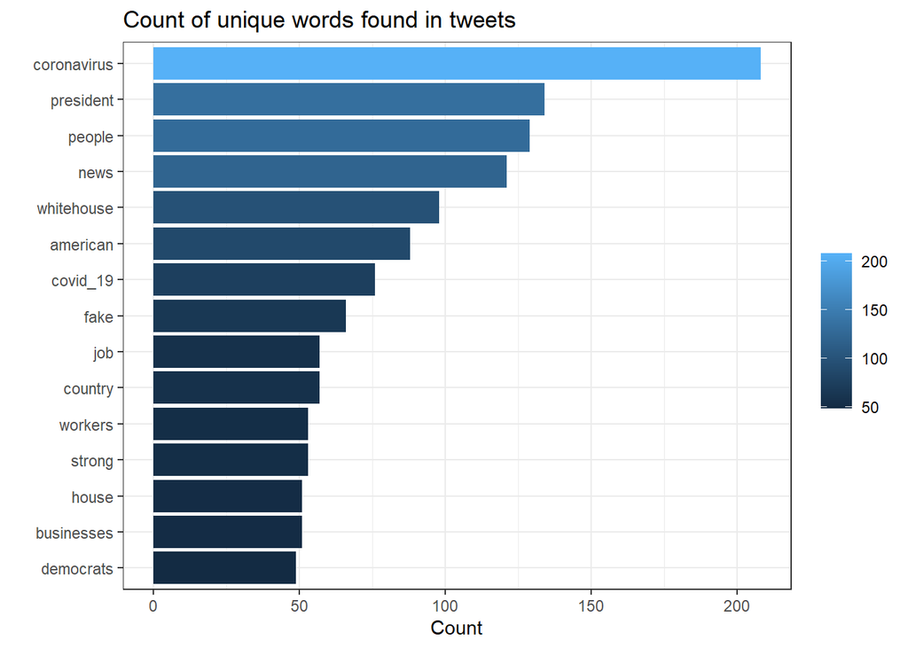

It can be seen that the words related to the corona occupied a significant part of the tweets,  
yet words like strength and pike played a central part,  
which can show on some intention the public opinion.

## We will continue to divide the words into emotions and we will examine whether there are more positive or negative words.

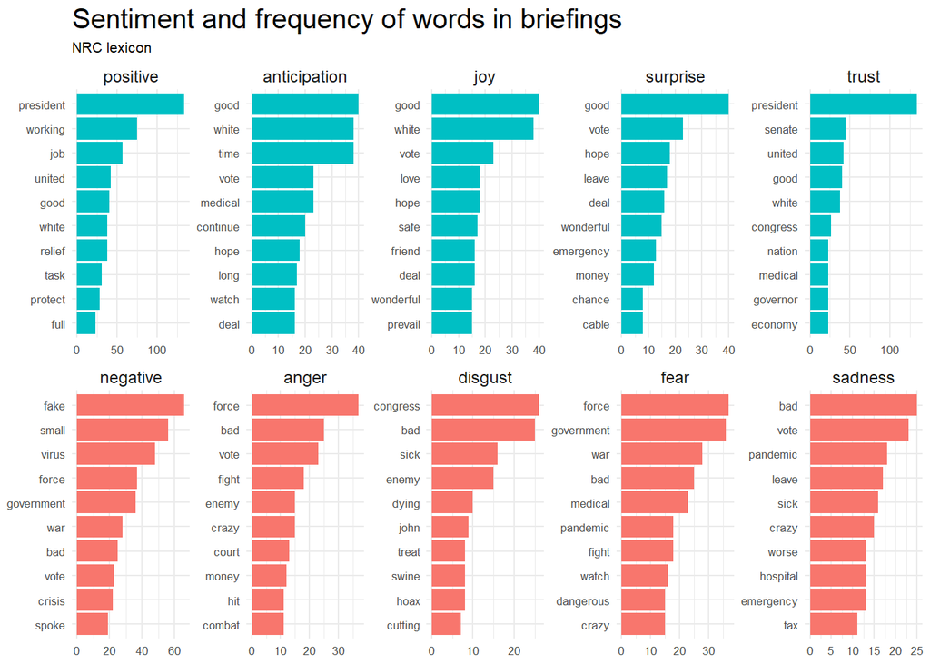

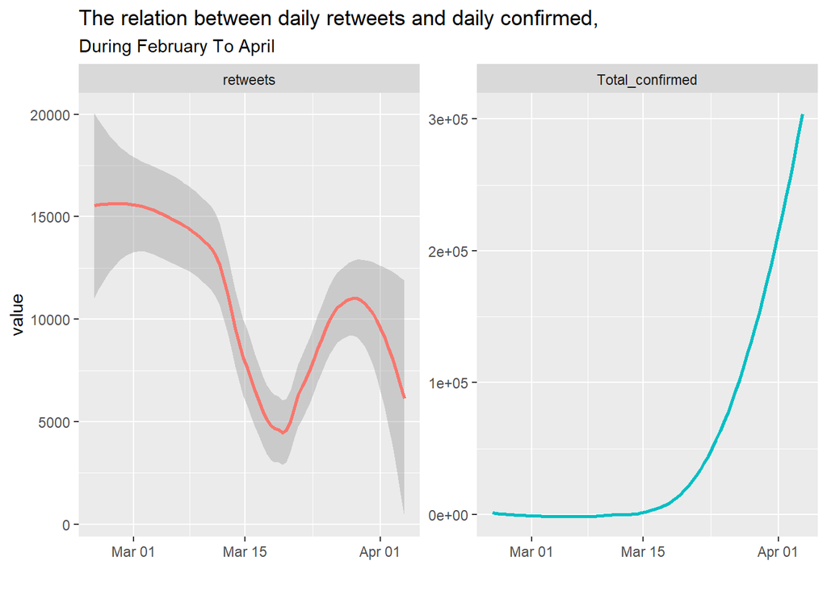

## relation between daily retweets and daily confirmed:

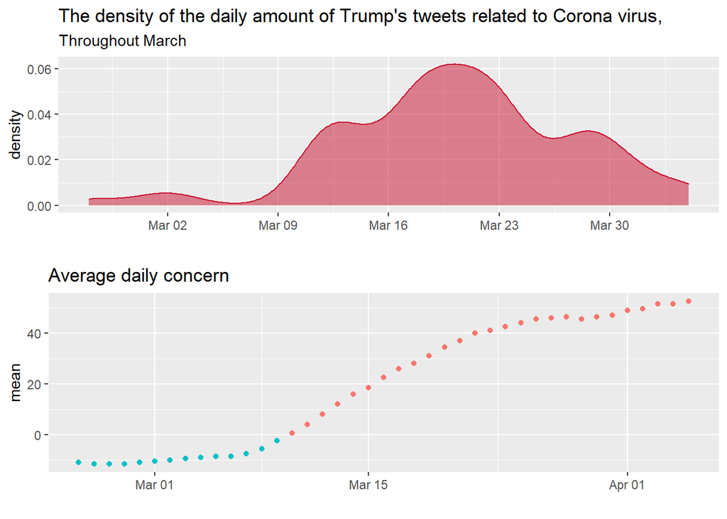

As we thought, from March start we can notice an increase in concern among all americans,  
probably because of the increase in the Covid-19 confirmes.

## Prepper Features to the model

- positive - sum of all positive words in the tweet
- negative - sum of all negative words in the tweet
- sum_val - sum of all values words
- count_tweet - number of tweet in a day
- retweets - number of people that retweet
- favorites - Daily likes
- sum_7r - mean words value calculate by avg of the previous 7 days

| tweet_num | date | positive | negative | count_tweet | retweets | favorites | sum_val | sum_7r | dem | rep | diff |
| --- | --- | --- | --- | --- | --- | --- | --- | --- | --- | --- | --- |
| 1 | 2020-02-25 | 0 | -2 | 1 | 25611 | 115307 | -2 | -2.000000 | 35 | -57 | 92 |
| 2 | 2020-02-26 | 9 | -31 | 8 | 271569 | 775258 | -22 | -12.000000 | 35 | -58 | 93 |
| 3 | 2020-02-28 | 5 | -34 | 6 | 389886 | 1577662 | -29 | -17.666667 | 35 | -58 | 93 |
| 4 | 2020-03-01 | 4 | -4 | 2 | 78335 | 341551 | 0 | -13.250000 | 37 | -58 | 95 |
| 5 | 2020-03-02 | 0 | -4 | 2 | 11561 | 0 | -4 | -11.400000 | 37 | -57 | 94 |
| 6 | 2020-03-03 | 4 | -2 | 2 | 27344 | 110370 | 2 | -9.166667 | 37 | -56 | 93 |

### Regration Model

creating a recipe according to the features calculated before.  
We didn’t use all the features, only the following: *dem* sum_7r *retweets* favorites  
those features were the most informative ones, and the ones which help predict the concern polls most accurate.  
Dem prediction

```
## # A tibble: 2 x 3
##   .metric   mean std_err
##   <chr>    <dbl>   <dbl>
## 1 rmse    11.1    1.03
## 2 rsq      0.810  0.0792
```

```
## # A tibble: 2 x 3
##   .metric   mean std_err
##   <chr>    <dbl>   <dbl>
## 1 rmse    10.4     2.23
## 2 rsq      0.655   0.146
```

```r
all1 <-full_join(rep_collect,dem_collect,by = c(".metric", "mean", "std_err"))
all <- full_join(all1,diff_collect,by = c(".metric", "mean", "std_err"))
all
```

```
## # A tibble: 6 x 3
##   .metric   mean std_err
##   <chr>    <dbl>   <dbl>
## 1 rmse    19.4    5.69
## 2 rsq      0.799  0.119
## 3 rmse    11.1    1.03
## 4 rsq      0.810  0.0792
## 5 rmse    10.4    2.23
## 6 rsq      0.655  0.146
```

```r
all[1,1] = "rmse_rep"
all[2,1] = "Pearson's_rep"
all[3,1] = "rmse_dem"
all[4,1] = "Pearson's_dem"
all[5,1] = "rmse_diff"
all[6,1] = "Pearson's_diff"

all <- all %>% dplyr::rename(Parameter_by_party = .metric)
all%>% kbl() %>%
  kable_material(c("striped", "hover"))
```

| Parameter_by_party | mean | std_err |
| --- | --- | --- |
| rmse_rep | 19.3526076 | 5.6937467 |
| Pearson’s_rep | 0.7993021 | 0.1194738 |
| rmse_dem | 11.0949190 | 1.0328524 |
| Pearson’s_dem | 0.8096289 | 0.0792272 |
| rmse_diff | 10.3975127 | 2.2260290 |
| Pearson’s_diff | 0.6554924 | 0.1458996 |